# Bayes Checkpoint 4

Erin Franke

### Libraries and data

```r
library(tidyverse)
library(lubridate)
library(readxl)
library(bayesrules)
library(tidyverse)
library(rstanarm)
library(broom.mixed)
library(tidybayes)
library(forcats)
library(bayesplot)
library(ggtext)
library(janitor)
library(gt)
library(tidymodels)
library(probably)
library(vip)
library(ggmosaic)
tidymodels_prefer()
`%!in%` <- Negate(`%in%`)

seasonal_complete <- read_csv("../data/seasonal_complete.csv")
```

### Introduction to the topic

A pitcher’s success can vary dramatically over the course of their major league career. 2015 Cy Young Jake Arrieta had tremendous success in the middle of his career, but began his career with the Orioles and pitched at levels far below league average. In more recent seasons he has also struggled. A good measure of this trend ERA+, which takes a player’s earned run average and normalizes across the entire league. An ERA+ of 100 represents league average, while one of 150 would represent 50% better than league average. As seen in the following graph, while many still think of Arrieta as legendary, the quality of his pitching has been slowly declining since his Cy Young season it is clear his value to a team is not the same as it once was.

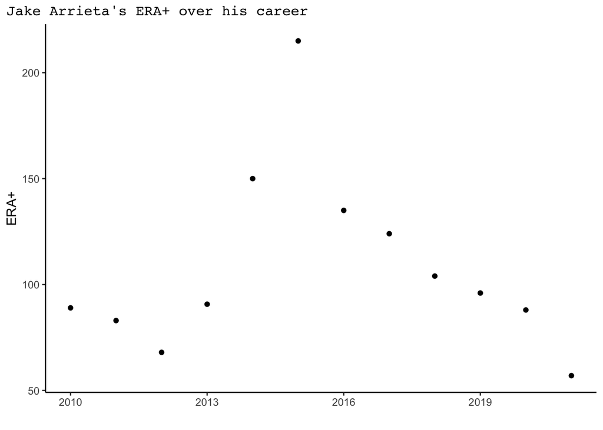

```r
seasonal_complete %>%
  filter(Player == "Jake Arrieta") %>%
  ggplot(aes(x=Year, y=`ERA+`))+
  geom_point()+
  theme_classic()+
  labs(x="", title = "Jake Arrieta's ERA+ over his career")+
  theme(plot.title.position = "plot",
        plot.title = element_text(family = "mono", size = 12))
```

Jake Arrieta is just one example of the type of trajectory a player’s career may take. Drew Smyly has had a lot of variability in his success as a pitcher, as seen below. While his first four seasons appeared quite strong, Smyly performed below average 2016 and 2019 and since has had a little more success.

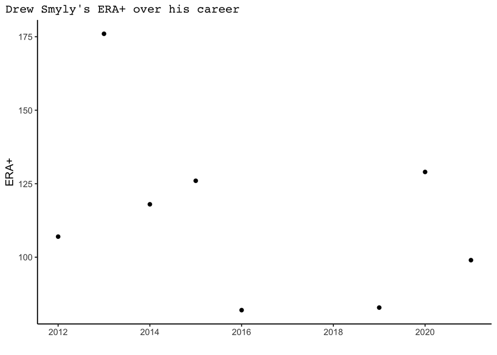

```r
seasonal_complete %>%
  filter(Player == "Drew Smyly") %>%
  ggplot(aes(x=Year, y=`ERA+`))+
  geom_point()+
  theme_classic()+
  labs(x="", title = "Drew Smyly's ERA+ over his career")+
  theme(plot.title.position = "plot",
        plot.title = element_text(family = "mono", size = 12))
```

What might contribute to these pitching trends? Notice Smyly’s missing stats in 2017 and 2018 - during this period, he underwent Tommy John surgery. Tommy John surgery is a major surgery that repairs a torn ulnar collateral ligament in the elbow by replacing it with a tendon from another part of a player’s body. Recovery typically takes a year, but can take up to 2.

In light of just a couple of these trends, this analysis will seek to understand how the trajectory of a pitcher’s MLB success changes over the course of his career. I will measure success in two forms: by WHIP to assess skill as well as innings pitched to measure longevity. In investigating this trajectory, we will especially focus on the impact of undergoing Tommy John surgery and try to weight the risk of signing a player that has had this surgery.

### Data

The data for this analysis were collected from multiple sources. I collected information on each player’s draft round and year from a GitHub source and checked these data for accuracy. I then joined these data by player name and birth date with career level pitcher statistics and debut information from Baseball Reference. Tommy John surgery information was obtained from MLB Reports, and finally individual player data on the seasonal level were downloaded from Stathead Baseball. The diversity of the downloaded data allowed me to create a database with a wide variety of variables, and enables the comparison between players as well as the analysis of a player’s development over the course of their career.

The variables that will be used most in this study are shown in the code below:

```r
codebook = data.frame(Variable = c("Player", "Year", "Age", "hs_draftee", "birth_date", "Debut", "round", "surgery1Year", "statsTime", "surgery1time", "ERA+", "G", "GS", "IP", "WHIP", "SO"),
                      Meaning = c("name of pitcher", "year of MLB season", "player age during season", "whether the player was drafted in high school", "player date of birth", "player MLB debut data", "the player's draft round", "the year the player had their first Tommy John surgery while in the MLB", "whether the stats for this season come before or after the player's first surgery", "whether the player's first surgery came before draft, between draft & debut, or after debut", "adjusts a pitcher's ERA according to the pitcher's ballpark and the ERA of the pitcher's league", "games played", "games started", "innings pitched", "number of walks + hits per inning pitched", "strikeouts"))
codebook %>%
  gt() %>%
  tab_header(
    title = md("**Codebook**")
  ) %>%
  tab_style(
    style = cell_fill(color = "honeydew"),
    locations = cells_body(
      rows = Variable %in% c("Player", "Age", "birth_date", "round", "statsTime", "ERA+", "GS", "WHIP"))) %>%
  tab_style(
    style = cell_fill(color = "lightcyan3"),
    locations = cells_body(
      rows = Variable %!in% c("Player", "Age", "birth_date", "round", "statsTime", "ERA+", "GS", "WHIP"))) %>%
  tab_options(
    table.font.size = px(13L)
  )
```

**Codebook**

| Variable | Meaning |
| --- | --- |
| Player | name of pitcher |
| Year | year of MLB season |
| Age | player age during season |
| hs_draftee | whether the player was drafted in high school |
| birth_date | player date of birth |
| Debut | player MLB debut data |
| round | the player's draft round |
| surgery1Year | the year the player had their first Tommy John surgery while in the MLB |
| statsTime | whether the stats for this season come before or after the player's first surgery |
| surgery1time | whether the player's first surgery came before draft, between draft & debut, or after debut |
| ERA+ | adjusts a pitcher's ERA according to the pitcher's ballpark and the ERA of the pitcher's league |
| G | games played |
| GS | games started |
| IP | innings pitched |
| WHIP | number of walks + hits per inning pitched |
| SO | strikeouts |

### Build a prior understanding

In understanding career longevity, we should first understand the age distribution of players in the MLB. Using all pitchers that played in the 2021 season, we get the following age distribution and see most pitchers are between their low twenties and thirties.

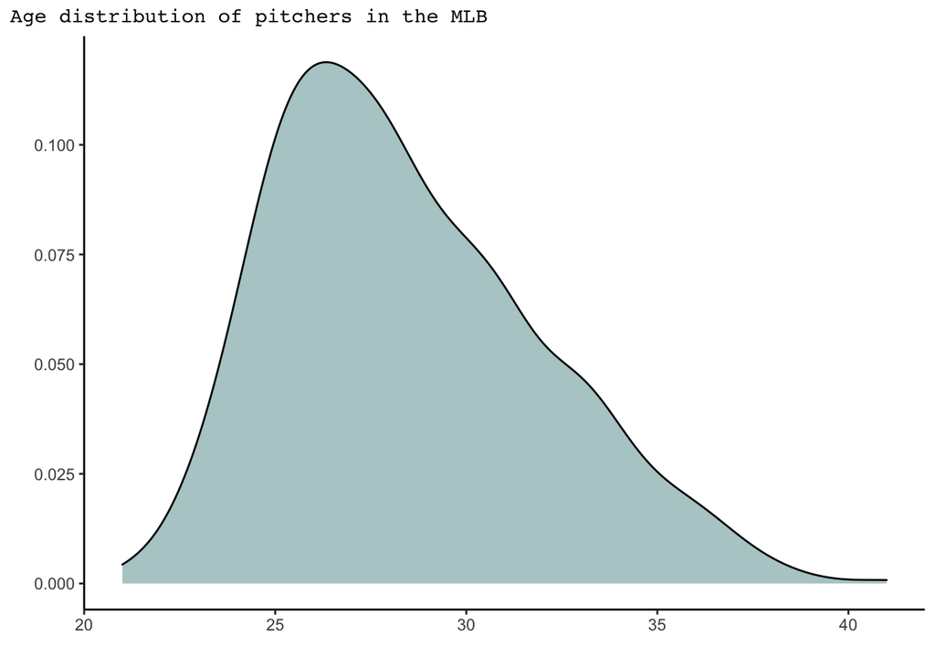

```r
seasonal_complete %>%
  filter(Year == 2021) %>%
  ggplot(aes(x=Age))+
  geom_density(fill = "lightcyan3")+
  theme_classic()+
  labs(title = "Age distribution of pitchers in the MLB", x="", y="")+
  theme(plot.title.position = "plot",
        plot.title = element_text(family = "mono", size = 11))
```

In trying to understand the impact of having Tommy John surgery on a player’s career, we should also seek to understand if there are differences in career length for players that receive the surgery. To do this, we compare the career length in seasons of players that did not have surgery at any point in their career to those that had surgery between their draft and debut date. We remove players that had surgery in the MLB for this graph - the fact that they made it far enough in their MLB career to have a surgery during it is an indicator of career length. Additionally, we do not include players that had surgery before being drafted as scouts deemed them worthy enough to be drafted despite their surgery. When looking at the graph, there do not seem to be any significant differences.

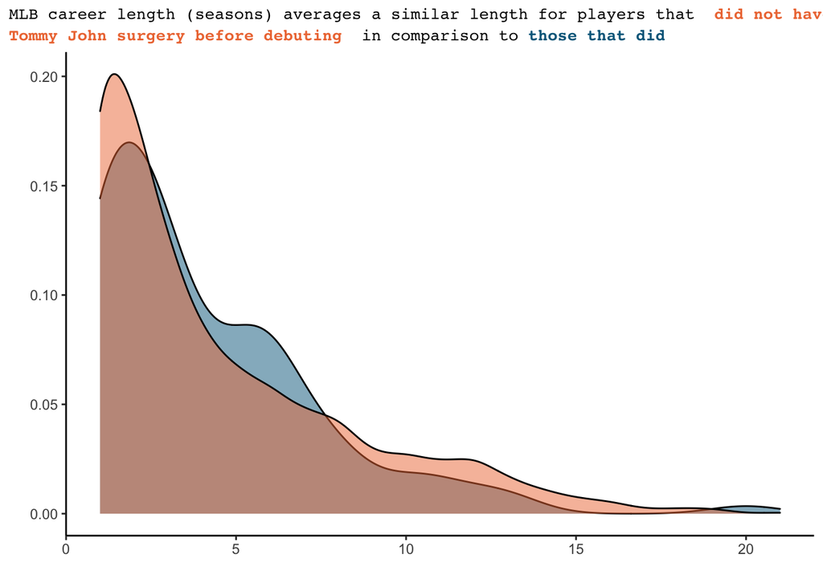

```r
seasonal_complete %>%
  filter(surgery1time %!in% c("after debut", "before draft")) %>%
  mutate(surgery1time = case_when(surgery1time == "between draft and debut" ~ "between draft and debut",
                                  TRUE ~ "no surgery")) %>%
  group_by(Player, surgery1time) %>%
  summarize(n = n(), lastyear = max(Year)) %>%
  filter(lastyear < 2020) %>%
  ggplot(aes(x=n, fill=surgery1time))+
  geom_density(alpha = 0.5)+
  theme_classic()+
  scale_fill_manual(values = c("deepskyblue4", "sienna2"))+
  labs(x="", y="", title = "MLB career length (seasons) averages a similar length for players that <strong><span style='color:sienna2'> did not have</span></strong></b>", subtitle = "<strong><span style='color:sienna2'> Tommy John surgery before debuting </span></strong></b> in comparison to <strong><span style='color:deepskyblue4'>those that did </span></strong></b>")+
  theme(plot.title = element_markdown(size = 10, family = "mono"),
        plot.subtitle = element_markdown(size = 10, family = "mono"),
        plot.title.position = "plot",
        legend.position = "none")
```

It is also a good idea to look into how statistics might compare for players before and after their Tommy John surgeries. For players that have their first Tommy John surgery post MLB-debut, we notice they tend to average more innings following the surgery if it is done while they are younger, but players that have this surgery done later in their careeer almost always average fewer innings after it.

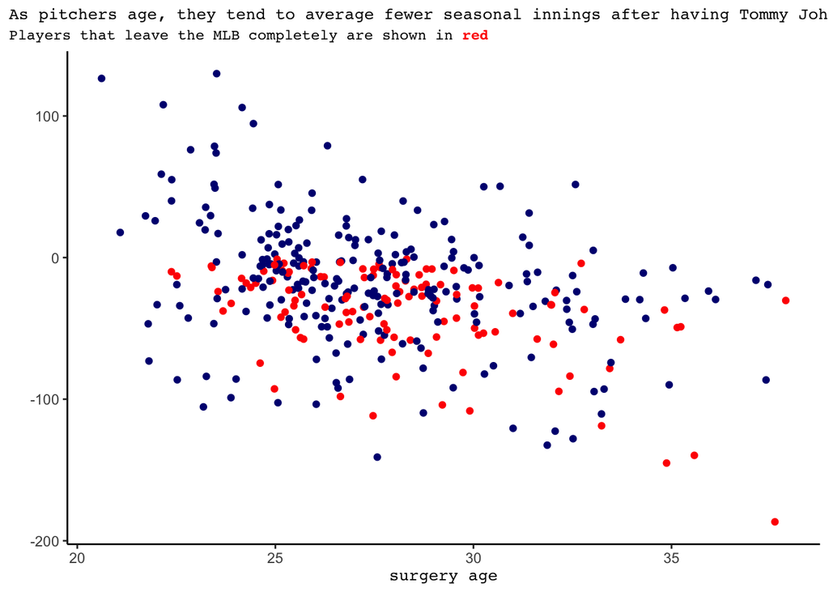

```r
diffIP <- seasonal_complete %>%
  filter(surgery1time == "after debut") %>%
  group_by(Player, statsTime) %>%
  summarize(avg_IP = round(mean(IP),2),
            surgery_age = time_length(difftime(`Surgery 1`, birth_date), "years")) %>%
  select(Player, surgery_age, statsTime, avg_IP) %>%
  distinct() %>%
  pivot_wider(id_cols = Player:surgery_age, names_from = statsTime, values_from = avg_IP)

diffIP$after <- replace_na(diffIP$after, 0)

diffIP %>%
  mutate(difference = after - before,
         leaveMLB = case_when(after == 0 ~ "leave MLB",
                              TRUE ~ "continue playing")) %>%
  ggplot(aes(x=surgery_age, y= difference, color = leaveMLB))+
  geom_point()+
  theme_classic()+
  geom_hline(yintercept = 0, linetype = "dashed", color = "red") %>%
  labs(title = "As pitchers age, they tend to average fewer seasonal innings after having Tommy John surgery than prior to it", subtitle = "Players that leave the MLB completely are shown in<strong><span style='color:red'> red</span></strong></b>", x = "surgery age", y = "")+
  theme(plot.title = element_markdown(size = 10, family = "mono"),
        plot.subtitle = element_markdown(size = 9, family = "mono"),
        plot.title.position = "plot",
        axis.title.x = element_markdown(size = 10, family = "mono"),
        legend.position = "none")+
  scale_color_manual(values = c("navy", "red"))
```

We can do a similar thing and look at how a pitcher’s success (perhaps measured by WHIP) might change for those that do come back and play in the MLB following their surgery.

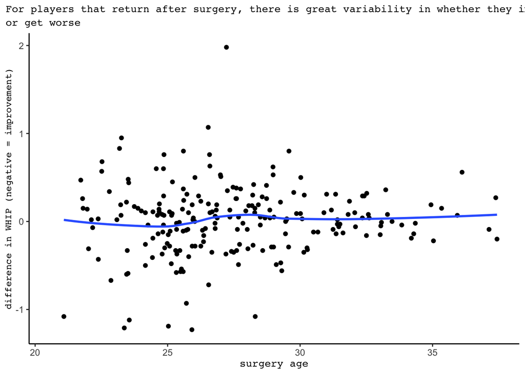

```r
diffWHIP <- seasonal_complete %>%
  filter(surgery1time == "after debut",
         IP > 5) %>%
  group_by(Player, statsTime) %>%
  summarize(avg_WHIP = round(mean(WHIP),2),
            surgery_age = time_length(difftime(`Surgery 1`, birth_date), "years")) %>%
  select(Player, surgery_age, statsTime, avg_WHIP) %>%
  distinct() %>%
  pivot_wider(id_cols = Player:surgery_age, names_from = statsTime, values_from = avg_WHIP)

diffWHIP %>%
  filter(!is.na(after)) %>%
  mutate(difference = after - before) %>%
  ggplot(aes(x=surgery_age, y= difference))+
  geom_point()+
  theme_classic()+
  geom_hline(yintercept = 0, linetype = "dashed", color = "red") %>%
  labs(title = "For players that return after surgery, there is great variability in whether they improve", subtitle = "or get worse", x = "surgery age", y = "difference in WHIP (negative = improvement)")+
  theme(plot.title = element_markdown(size = 10, family = "mono"),
        plot.subtitle = element_markdown(size = 10, family = "mono"),
        plot.title.position = "plot",
        axis.title.y = element_markdown(size = 9, family = "mono"),
        axis.title.x = element_markdown(size = 10, family = "mono"))+
  geom_smooth(se=FALSE)
```

### Model 1: Classification for if a player will play again

**For players that have their first Tommy John surgery following their debut, what is the likelihood they play again?**

#### Get data ready

Filter for players that had their first surgery after debuting. Create an indicator variable for if the player plays following their surgery.

```r
play_post_surgery <- seasonal_complete %>%
  filter(surgery1time == "after debut", surgery1Year < 2020) %>%
  group_by(Player) %>%
  count(statsTime) %>%
  pivot_wider(id_cols = Player, names_from = statsTime, values_from = n) %>%
  mutate(played_after = case_when(is.na(after) == TRUE ~ 0,
                                  TRUE ~ 1))

# 73.27% of players play following their surgery
play_post_surgery %>%
  tabyl(played_after)
```

```
##  played_after   n   percent
##             0  85 0.2672956
##             1 233 0.7327044
```

Join this data with `seasonal_complete` to get more information about these players. Currently, this data is not grouped by player.

```r
seasonal_SurgPostdebut <- seasonal_complete %>%
  filter(surgery1time == "after debut", surgery1Year < 2020) %>%
  left_join(play_post_surgery, by = "Player")
```

Group the data by player and select the variables of interest.

```r
stats <- seasonal_SurgPostdebut %>%
  filter(statsTime == "before", WHIP < 100) %>%
  group_by(Player) %>%
  mutate(surgery_age = time_length(difftime(`Surgery 1`, birth_date), "years"),
         games_started = sum(GS),
         games = sum(G),
         starter = case_when(games_started/games < 0.5 ~ 0,
                                TRUE ~ 1),
         totalIP = sum(IP),
         kRate = sum(SO)/totalIP,
         totwalks = sum(BB),
         totH = sum(H),
         avgWHIP = (totwalks+totH)/totalIP) %>%
  select(hs_draftee, played_after, surgery_age, starter, kRate, totalIP, avgWHIP) %>%
  distinct()

#get a sense of this data -  we have information on 318 players and 1282 seasons total
head(stats)
```

```
## # A tibble: 6 × 8
## # Groups:   Player [6]
##   Player         hs_draftee played_after surgery_age starter kRate totalIP avgWHIP
##   <chr>          <lgl>             <dbl>       <dbl>   <dbl> <dbl>   <dbl>   <dbl>
## 1 Corbin Martin  FALSE                 1        23.5       1 0.995    19.1    1.83
## 2 Ryan Burr      FALSE                 1        25.1       0 0.915    28.4    1.51
## 3 Michael Kopech TRUE                  1        22.4       1 1.06     14.1    1.56
## 4 Drew Smith     FALSE                 1        25.5       0 0.643    28      1.43
## 5 Jerry Vasto    FALSE                 0        26.6       0 1.18      3.4    2.35
## 6 Jordan Hicks   TRUE                  1        22.8       0 0.958   105.     1.24
```

```r
dim(stats)
```

```
## [1] 318   8
```